# Risk Factor Analysis

## Outcome Variable

**Outcome Variable:** stunted

## Predictor Variables

**Intervention Variable:** tr

**Adjustment Set:**

unadjusted

## Stratifying Variables

The analysis was stratified on these variable(s):

- agecat
- studyid
- country

## Data Summary

| agecat | studyid | country | stunted | n_cell | n |
| --- | --- | --- | --- | --- | --- |
| Birth | iLiNS_DYADM_LNS | MALAWI | 0 | 0 | 1 |
| Birth | iLiNS_DYADM_LNS | MALAWI | 1 | 1 | 1 |
| Birth | ki1000125-AgaKhanUniv | PAKISTAN | 0 | 11 | 11 |
| Birth | ki1000125-AgaKhanUniv | PAKISTAN | 1 | 0 | 11 |
| Birth | ki1000304b-SAS-CompFeed | INDIA | 0 | 106 | 144 |
| Birth | ki1000304b-SAS-CompFeed | INDIA | 1 | 38 | 144 |
| Birth | ki1119695-PROBIT | BELARUS | 0 | 13851 | 13884 |
| Birth | ki1119695-PROBIT | BELARUS | 1 | 33 | 13884 |
| Birth | ki1126311-ZVITAMBO | ZIMBABWE | 0 | 12398 | 13830 |
| Birth | ki1126311-ZVITAMBO | ZIMBABWE | 1 | 1432 | 13830 |
| Birth | ki1135781-COHORTS | GUATEMALA | 0 | 802 | 852 |
| Birth | ki1135781-COHORTS | GUATEMALA | 1 | 50 | 852 |
| Birth | ki1148112-iLiNS-DYAD-M | MALAWI | 0 | 0 | 1 |
| Birth | ki1148112-iLiNS-DYAD-M | MALAWI | 1 | 1 | 1 |
| Birth | kiGH5241-JiVitA-3 | BANGLADESH | 0 | 26550 | 39226 |
| Birth | kiGH5241-JiVitA-3 | BANGLADESH | 1 | 12676 | 39226 |
| Birth | kiGH5241-JiVitA-4 | BANGLADESH | 0 | 1150 | 1644 |
| Birth | kiGH5241-JiVitA-4 | BANGLADESH | 1 | 494 | 1644 |
| 6 months | iLiNS_DYADM_LNS | MALAWI | 0 | 528 | 683 |
| 6 months | iLiNS_DYADM_LNS | MALAWI | 1 | 155 | 683 |
| 6 months | ki1000107-Serrinha-VitA | BRAZIL | 0 | 26 | 35 |
| 6 months | ki1000107-Serrinha-VitA | BRAZIL | 1 | 9 | 35 |
| 6 months | ki1000110-WASH-Bangladesh | BANGLADESH | 0 | 582 | 682 |
| 6 months | ki1000110-WASH-Bangladesh | BANGLADESH | 1 | 100 | 682 |
| 6 months | ki1000111-WASH-Kenya | KENYA | 0 | 63 | 74 |
| 6 months | ki1000111-WASH-Kenya | KENYA | 1 | 11 | 74 |
| 6 months | ki1000125-AgaKhanUniv | PAKISTAN | 0 | 493 | 695 |
| 6 months | ki1000125-AgaKhanUniv | PAKISTAN | 1 | 202 | 695 |
| 6 months | ki1000304-EU | INDIA | 0 | 246 | 363 |
| 6 months | ki1000304-EU | INDIA | 1 | 117 | 363 |

[output cut: 72 more lines]

The following strata were considered:

- agecat: 24 months, studyid: iLiNS_DYADM_LNS, country: MALAWI
- agecat: 24 months, studyid: ki1000107-Serrinha-VitA, country: BRAZIL
- agecat: 24 months, studyid: ki1000110-WASH-Bangladesh, country: BANGLADESH
- agecat: 24 months, studyid: ki1000111-WASH-Kenya, country: KENYA
- agecat: 24 months, studyid: ki1000125-AgaKhanUniv, country: PAKISTAN
- agecat: 24 months, studyid: ki1000304-EU, country: INDIA
- agecat: 24 months, studyid: ki1000304-Vitamin-B12, country: INDIA
- agecat: 24 months, studyid: ki1000304-ZnMort, country: INDIA
- agecat: 24 months, studyid: ki1017093b-PROVIDE, country: BANGLADESH
- agecat: 24 months, studyid: ki1066203-TanzaniaChild2, country: TANZANIA, UNITED REPUBLIC OF
- agecat: 24 months, studyid: ki1112895-Burkina Faso Zn, country: BURKINA FASO
- agecat: 24 months, studyid: ki1119695-PROBIT, country: BELARUS
- agecat: 24 months, studyid: ki1126311-ZVITAMBO, country: ZIMBABWE
- agecat: 24 months, studyid: ki1135781-COHORTS, country: GUATEMALA
- agecat: 24 months, studyid: ki1148112-iLiNS-DOSE, country: MALAWI
- agecat: 24 months, studyid: ki1148112-iLiNS-DYAD-M, country: MALAWI
- agecat: 24 months, studyid: ki1148112-LCNI-5, country: MALAWI
- agecat: 24 months, studyid: kiGH5241-JiVitA-3, country: BANGLADESH
- agecat: 24 months, studyid: kiGH5241-JiVitA-4, country: BANGLADESH
- agecat: 6 months, studyid: iLiNS_DYADM_LNS, country: MALAWI
- agecat: 6 months, studyid: ki1000107-Serrinha-VitA, country: BRAZIL
- agecat: 6 months, studyid: ki1000110-WASH-Bangladesh, country: BANGLADESH
- agecat: 6 months, studyid: ki1000111-WASH-Kenya, country: KENYA
- agecat: 6 months, studyid: ki1000125-AgaKhanUniv, country: PAKISTAN
- agecat: 6 months, studyid: ki1000304-EU, country: INDIA
- agecat: 6 months, studyid: ki1000304-VITAMIN-A, country: INDIA
- agecat: 6 months, studyid: ki1000304-Vitamin-B12, country: INDIA
- agecat: 6 months, studyid: ki1000304-ZnMort, country: INDIA
- agecat: 6 months, studyid: ki1000304b-SAS-CompFeed, country: INDIA
- agecat: 6 months, studyid: ki1000304b-SAS-FoodSuppl, country: INDIA
- agecat: 6 months, studyid: ki1017093b-PROVIDE, country: BANGLADESH
- agecat: 6 months, studyid: ki1066203-TanzaniaChild2, country: TANZANIA, UNITED REPUBLIC OF
- agecat: 6 months, studyid: ki1112895-Burkina Faso Zn, country: BURKINA FASO
- agecat: 6 months, studyid: ki1112895-Guatemala BSC, country: GUATEMALA
- agecat: 6 months, studyid: ki1119695-PROBIT, country: BELARUS
- agecat: 6 months, studyid: ki1126311-ZVITAMBO, country: ZIMBABWE
- agecat: 6 months, studyid: ki1135781-COHORTS, country: GUATEMALA
- agecat: 6 months, studyid: ki1148112-iLiNS-DOSE, country: MALAWI
- agecat: 6 months, studyid: ki1148112-iLiNS-DYAD-M, country: MALAWI
- agecat: 6 months, studyid: ki1148112-LCNI-5, country: MALAWI
- agecat: 6 months, studyid: kiGH5241-JiVitA-3, country: BANGLADESH
- agecat: 6 months, studyid: kiGH5241-JiVitA-4, country: BANGLADESH
- agecat: Birth, studyid: iLiNS_DYADM_LNS, country: MALAWI
- agecat: Birth, studyid: ki1000125-AgaKhanUniv, country: PAKISTAN
- agecat: Birth, studyid: ki1000304b-SAS-CompFeed, country: INDIA
- agecat: Birth, studyid: ki1119695-PROBIT, country: BELARUS
- agecat: Birth, studyid: ki1126311-ZVITAMBO, country: ZIMBABWE
- agecat: Birth, studyid: ki1135781-COHORTS, country: GUATEMALA
- agecat: Birth, studyid: ki1148112-iLiNS-DYAD-M, country: MALAWI
- agecat: Birth, studyid: kiGH5241-JiVitA-3, country: BANGLADESH
- agecat: Birth, studyid: kiGH5241-JiVitA-4, country: BANGLADESH

### Dropped Strata

Some strata were dropped due to rare outcomes:

- agecat: Birth, studyid: iLiNS_DYADM_LNS, country: MALAWI
- agecat: Birth, studyid: ki1000125-AgaKhanUniv, country: PAKISTAN
- agecat: Birth, studyid: ki1148112-iLiNS-DYAD-M, country: MALAWI
- agecat: 24 months, studyid: ki1000125-AgaKhanUniv, country: PAKISTAN
- agecat: 24 months, studyid: ki1017093b-PROVIDE, country: BANGLADESH
- agecat: 24 months, studyid: ki1066203-TanzaniaChild2, country: TANZANIA, UNITED REPUBLIC OF

## Methods Detail

We’re interested in the causal parameters $E[Y_a]$ for all values of $a \in \mathcal{A}$. These parameters represent the mean outcome if, possibly contrary to fact, we intervened to set all units to have $A=a$. Under the randomization and positivity assumptions, these are identified by the statistical parameters $\psi_a=E_W[E_{Y|A,W}(Y|A=a,W)]$. In addition, we’re interested in the mean of $Y$, $E[Y]$ under no intervention (the observed mean). We will estimate these parameters by using SuperLearner to fit the relevant likelihood factors – $E_{Y|A,W}(Y|A=a,W)$ and $p(A=a|W)$, and then updating our likelihood fit using a joint TMLE.

For unadjusted analyses ($W=\{\}$), initial likelihoods were estimated using Lrnr_glm to estimate the simple $E(Y|A)$ and Lrnr_mean to estimate $p(A)$. For adjusted analyses, a small library containing Lrnr_glmnet, Lrnr_xgboost, and Lrnr_mean was used.

Having estimated these parameters, we will then use the delta method to estimate relative risks and attributable risks relative to a prespecified baseline level of $A$.

# Results Detail

## Results Plots

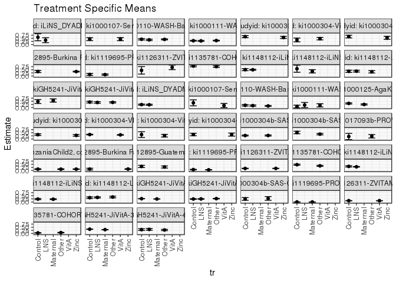

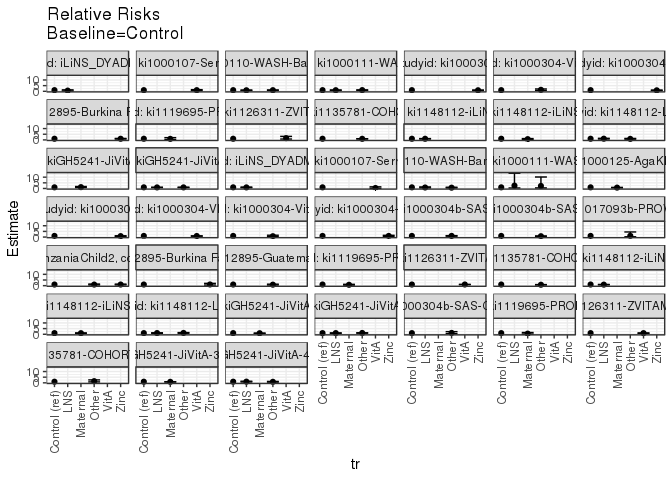

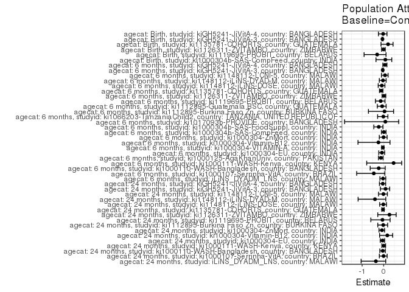

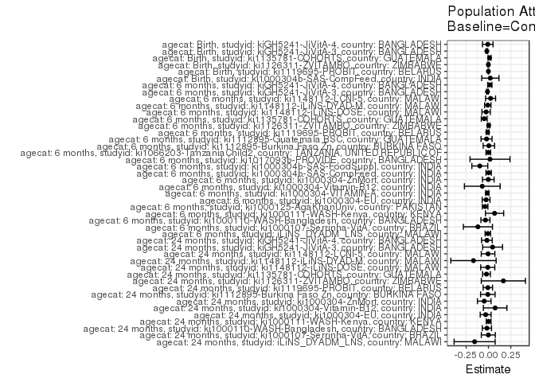

## Results Table

### Parameter: TSM

| agecat | studyid | country | intervention_level | baseline_level | estimate | ci_lower | ci_upper |
| --- | --- | --- | --- | --- | --- | --- | --- |
| Birth | ki1000304b-SAS-CompFeed | INDIA | Control | NA | 0.2428571 | 0.1331025 | 0.3526118 |
| Birth | ki1000304b-SAS-CompFeed | INDIA | Other | NA | 0.2837838 | 0.1362664 | 0.4313011 |
| Birth | ki1119695-PROBIT | BELARUS | Control | NA | 0.0030978 | 0.0008776 | 0.0053180 |
| Birth | ki1119695-PROBIT | BELARUS | Maternal | NA | 0.0016890 | 0.0004528 | 0.0029251 |
| Birth | ki1126311-ZVITAMBO | ZIMBABWE | Control | NA | 0.1043781 | 0.0941738 | 0.1145824 |
| Birth | ki1126311-ZVITAMBO | ZIMBABWE | VitA | NA | 0.1032656 | 0.0974116 | 0.1091196 |
| Birth | ki1135781-COHORTS | GUATEMALA | Control | NA | 0.0466830 | 0.0261760 | 0.0671901 |
| Birth | ki1135781-COHORTS | GUATEMALA | Other | NA | 0.0696629 | 0.0459959 | 0.0933300 |
| Birth | kiGH5241-JiVitA-3 | BANGLADESH | Control | NA | 0.3412682 | 0.3306851 | 0.3518513 |
| Birth | kiGH5241-JiVitA-3 | BANGLADESH | Maternal | NA | 0.3052600 | 0.2946370 | 0.3158829 |
| Birth | kiGH5241-JiVitA-4 | BANGLADESH | Control | NA | 0.3080357 | 0.2378939 | 0.3781775 |
| Birth | kiGH5241-JiVitA-4 | BANGLADESH | LNS | NA | 0.3259912 | 0.2564599 | 0.3955224 |
| Birth | kiGH5241-JiVitA-4 | BANGLADESH | Other | NA | 0.2803235 | 0.2294740 | 0.3311729 |
| 6 months | iLiNS_DYADM_LNS | MALAWI | Control | NA | 0.2336182 | 0.1893198 | 0.2779167 |
| 6 months | iLiNS_DYADM_LNS | MALAWI | LNS | NA | 0.2198795 | 0.1752964 | 0.2644626 |
| 6 months | ki1000107-Serrinha-VitA | BRAZIL | Control | NA | 0.3750000 | 0.1343209 | 0.6156791 |
| 6 months | ki1000107-Serrinha-VitA | BRAZIL | VitA | NA | 0.1578947 | -0.0084591 | 0.3242486 |
| 6 months | ki1000110-WASH-Bangladesh | BANGLADESH | Control | NA | 0.1801242 | 0.1207205 | 0.2395280 |
| 6 months | ki1000110-WASH-Bangladesh | BANGLADESH | LNS | NA | 0.1542553 | 0.1025866 | 0.2059240 |
| 6 months | ki1000110-WASH-Bangladesh | BANGLADESH | Other | NA | 0.1261261 | 0.0904423 | 0.1618100 |
| 6 months | ki1000111-WASH-Kenya | KENYA | Control | NA | 0.0800000 | -0.0270709 | 0.1870709 |
| 6 months | ki1000111-WASH-Kenya | KENYA | LNS | NA | 0.2000000 | -0.0038060 | 0.4038060 |
| 6 months | ki1000111-WASH-Kenya | KENYA | Other | NA | 0.1764706 | 0.0474560 | 0.3054852 |
| 6 months | ki1000125-AgaKhanUniv | PAKISTAN | Control | NA | 0.3280000 | 0.2804482 | 0.3755518 |
| 6 months | ki1000125-AgaKhanUniv | PAKISTAN | Maternal | NA | 0.2468750 | 0.1995971 | 0.2941529 |
| 6 months | ki1000304-EU | INDIA | Control | NA | 0.3484848 | 0.2820236 | 0.4149461 |
| 6 months | ki1000304-EU | INDIA | Zinc | NA | 0.2909091 | 0.2215130 | 0.3603051 |
| 6 months | ki1000304-VITAMIN-A | INDIA | Control | NA | 0.3573123 | 0.3308995 | 0.3837250 |
| 6 months | ki1000304-VITAMIN-A | INDIA | VitA | NA | 0.3314562 | 0.3052817 | 0.3576306 |
| 6 months | ki1000304-Vitamin-B12 | INDIA | Control | NA | 0.3529412 | 0.1243580 | 0.5815243 |

[output cut: 70 more lines]

### Parameter: E(Y)

| agecat | studyid | country | intervention_level | baseline_level | estimate | ci_lower | ci_upper |
| --- | --- | --- | --- | --- | --- | --- | --- |
| Birth | ki1000304b-SAS-CompFeed | INDIA | NA | NA | 0.2638889 | 0.1700887 | 0.3576891 |
| Birth | ki1119695-PROBIT | BELARUS | NA | NA | 0.0023768 | 0.0010945 | 0.0036592 |
| Birth | ki1126311-ZVITAMBO | ZIMBABWE | NA | NA | 0.1035430 | 0.0984652 | 0.1086208 |
| Birth | ki1135781-COHORTS | GUATEMALA | NA | NA | 0.0586854 | 0.0428942 | 0.0744767 |
| Birth | kiGH5241-JiVitA-3 | BANGLADESH | NA | NA | 0.3231530 | 0.3154984 | 0.3308077 |
| Birth | kiGH5241-JiVitA-4 | BANGLADESH | NA | NA | 0.3004866 | 0.2649179 | 0.3360553 |
| 6 months | iLiNS_DYADM_LNS | MALAWI | NA | NA | 0.2269400 | 0.1955046 | 0.2583753 |
| 6 months | ki1000107-Serrinha-VitA | BRAZIL | NA | NA | 0.2571429 | 0.1102338 | 0.4040519 |
| 6 months | ki1000110-WASH-Bangladesh | BANGLADESH | NA | NA | 0.1466276 | 0.1200600 | 0.1731951 |
| 6 months | ki1000111-WASH-Kenya | KENYA | NA | NA | 0.1486486 | 0.0670427 | 0.2302545 |
| 6 months | ki1000125-AgaKhanUniv | PAKISTAN | NA | NA | 0.2906475 | 0.2568657 | 0.3244293 |
| 6 months | ki1000304-EU | INDIA | NA | NA | 0.3223140 | 0.2741694 | 0.3704587 |
| 6 months | ki1000304-VITAMIN-A | INDIA | NA | NA | 0.3444976 | 0.3258960 | 0.3630992 |
| 6 months | ki1000304-Vitamin-B12 | INDIA | NA | NA | 0.2839506 | 0.1851417 | 0.3827595 |
| 6 months | ki1000304-ZnMort | INDIA | NA | NA | 0.3586207 | 0.2802882 | 0.4369532 |
| 6 months | ki1000304b-SAS-CompFeed | INDIA | NA | NA | 0.2803890 | 0.2513583 | 0.3094196 |
| 6 months | ki1000304b-SAS-FoodSuppl | INDIA | NA | NA | 0.4253521 | 0.3738504 | 0.4768538 |
| 6 months | ki1017093b-PROVIDE | BANGLADESH | NA | NA | 0.2173913 | 0.0968779 | 0.3379047 |
| 6 months | ki1066203-TanzaniaChild2 | TANZANIA, UNITED REPUBLIC OF | NA | NA | 0.1089631 | 0.0941772 | 0.1237489 |
| 6 months | ki1112895-Burkina Faso Zn | BURKINA FASO | NA | NA | 0.1158730 | 0.0908597 | 0.1408863 |
| 6 months | ki1112895-Guatemala BSC | GUATEMALA | NA | NA | 0.3027523 | 0.2416221 | 0.3638824 |
| 6 months | ki1119695-PROBIT | BELARUS | NA | NA | 0.0637241 | 0.0488374 | 0.0786108 |
| 6 months | ki1126311-ZVITAMBO | ZIMBABWE | NA | NA | 0.1658951 | 0.1576266 | 0.1741635 |
| 6 months | ki1135781-COHORTS | GUATEMALA | NA | NA | 0.4173820 | 0.3857058 | 0.4490581 |
| 6 months | ki1148112-iLiNS-DOSE | MALAWI | NA | NA | 0.3020725 | 0.2815825 | 0.3225626 |
| 6 months | ki1148112-iLiNS-DYAD-M | MALAWI | NA | NA | 0.2264334 | 0.2008493 | 0.2520176 |
| 6 months | ki1148112-LCNI-5 | MALAWI | NA | NA | 0.3682956 | 0.3356382 | 0.4009530 |
| 6 months | kiGH5241-JiVitA-3 | BANGLADESH | NA | NA | 0.2514112 | 0.2432817 | 0.2595406 |
| 6 months | kiGH5241-JiVitA-4 | BANGLADESH | NA | NA | 0.2536757 | 0.2392674 | 0.2680840 |
| 24 months | iLiNS_DYADM_LNS | MALAWI | NA | NA | 0.4285714 | 0.2622297 | 0.5949132 |
| 24 months | ki1000107-Serrinha-VitA | BRAZIL | NA | NA | 0.4351145 | 0.3498912 | 0.5203378 |
| 24 months | ki1000110-WASH-Bangladesh | BANGLADESH | NA | NA | 0.4069082 | 0.3789496 | 0.4348667 |
| 24 months | ki1000111-WASH-Kenya | KENYA | NA | NA | 0.3087456 | 0.2897118 | 0.3277794 |
| 24 months | ki1000304-EU | INDIA | NA | NA | 0.6007905 | 0.5403247 | 0.6612563 |
| 24 months | ki1000304-Vitamin-B12 | INDIA | NA | NA | 0.4436090 | 0.3588568 | 0.5283613 |
| 24 months | ki1000304-ZnMort | INDIA | NA | NA | 0.5928571 | 0.5111821 | 0.6745321 |
| 24 months | ki1112895-Burkina Faso Zn | BURKINA FASO | NA | NA | 0.3567151 | 0.3292432 | 0.3841871 |
| 24 months | ki1119695-PROBIT | BELARUS | NA | NA | 0.1189061 | 0.0738430 | 0.1639691 |
| 24 months | ki1126311-ZVITAMBO | ZIMBABWE | NA | NA | 0.6216216 | 0.4631969 | 0.7800464 |
| 24 months | ki1135781-COHORTS | GUATEMALA | NA | NA | 0.7791045 | 0.7346141 | 0.8235949 |
| 24 months | ki1148112-iLiNS-DOSE | MALAWI | NA | NA | 0.5038660 | 0.4686650 | 0.5390669 |
| 24 months | ki1148112-iLiNS-DYAD-M | MALAWI | NA | NA | 0.4153846 | 0.2946537 | 0.5361155 |
| 24 months | ki1148112-LCNI-5 | MALAWI | NA | NA | 0.3740260 | 0.3256297 | 0.4224222 |
| 24 months | kiGH5241-JiVitA-3 | BANGLADESH | NA | NA | 0.5253165 | 0.4248368 | 0.6257961 |
| 24 months | kiGH5241-JiVitA-4 | BANGLADESH | NA | NA | 0.4161677 | 0.3814286 | 0.4509067 |

### Parameter: RR

| agecat | studyid | country | intervention_level | baseline_level | estimate | ci_lower | ci_upper |
| --- | --- | --- | --- | --- | --- | --- | --- |
| Birth | ki1000304b-SAS-CompFeed | INDIA | Control | Control | 1.0000000 | 1.0000000 | 1.0000000 |
| Birth | ki1000304b-SAS-CompFeed | INDIA | Other | Control | 1.1685215 | 0.5864380 | 2.3283661 |
| Birth | ki1119695-PROBIT | BELARUS | Control | Control | 1.0000000 | 1.0000000 | 1.0000000 |
| Birth | ki1119695-PROBIT | BELARUS | Maternal | Control | 0.5452096 | 0.1955764 | 1.5198843 |
| Birth | ki1126311-ZVITAMBO | ZIMBABWE | Control | Control | 1.0000000 | 1.0000000 | 1.0000000 |
| Birth | ki1126311-ZVITAMBO | ZIMBABWE | VitA | Control | 0.9893416 | 0.8836223 | 1.1077096 |
| Birth | ki1135781-COHORTS | GUATEMALA | Control | Control | 1.0000000 | 1.0000000 | 1.0000000 |
| Birth | ki1135781-COHORTS | GUATEMALA | Other | Control | 1.4922531 | 0.8563787 | 2.6002739 |
| Birth | kiGH5241-JiVitA-3 | BANGLADESH | Control | Control | 1.0000000 | 1.0000000 | 1.0000000 |
| Birth | kiGH5241-JiVitA-3 | BANGLADESH | Maternal | Control | 0.8944869 | 0.8537410 | 0.9371776 |
| Birth | kiGH5241-JiVitA-4 | BANGLADESH | Control | Control | 1.0000000 | 1.0000000 | 1.0000000 |
| Birth | kiGH5241-JiVitA-4 | BANGLADESH | LNS | Control | 1.0582902 | 0.7746526 | 1.4457813 |
| Birth | kiGH5241-JiVitA-4 | BANGLADESH | Other | Control | 0.9100355 | 0.6801878 | 1.2175531 |
| 6 months | iLiNS_DYADM_LNS | MALAWI | Control | Control | 1.0000000 | 1.0000000 | 1.0000000 |
| 6 months | iLiNS_DYADM_LNS | MALAWI | LNS | Control | 0.9411916 | 0.7130390 | 1.2423466 |
| 6 months | ki1000107-Serrinha-VitA | BRAZIL | Control | Control | 1.0000000 | 1.0000000 | 1.0000000 |
| 6 months | ki1000107-Serrinha-VitA | BRAZIL | VitA | Control | 0.4210526 | 0.1226198 | 1.4458132 |
| 6 months | ki1000110-WASH-Bangladesh | BANGLADESH | Control | Control | 1.0000000 | 1.0000000 | 1.0000000 |
| 6 months | ki1000110-WASH-Bangladesh | BANGLADESH | LNS | Control | 0.8563830 | 0.5352078 | 1.3702936 |
| 6 months | ki1000110-WASH-Bangladesh | BANGLADESH | Other | Control | 0.7002175 | 0.4534432 | 1.0812918 |
| 6 months | ki1000111-WASH-Kenya | KENYA | Control | Control | 1.0000000 | 1.0000000 | 1.0000000 |
| 6 months | ki1000111-WASH-Kenya | KENYA | LNS | Control | 2.5000000 | 0.4649245 | 13.4430430 |
| 6 months | ki1000111-WASH-Kenya | KENYA | Other | Control | 2.2058824 | 0.4800253 | 10.1367924 |
| 6 months | ki1000125-AgaKhanUniv | PAKISTAN | Control | Control | 1.0000000 | 1.0000000 | 1.0000000 |
| 6 months | ki1000125-AgaKhanUniv | PAKISTAN | Maternal | Control | 0.7526677 | 0.5919560 | 0.9570115 |
| 6 months | ki1000304-EU | INDIA | Control | Control | 1.0000000 | 1.0000000 | 1.0000000 |
| 6 months | ki1000304-EU | INDIA | Zinc | Control | 0.8347826 | 0.6150830 | 1.1329561 |
| 6 months | ki1000304-VITAMIN-A | INDIA | Control | Control | 1.0000000 | 1.0000000 | 1.0000000 |
| 6 months | ki1000304-VITAMIN-A | INDIA | VitA | Control | 0.9276372 | 0.8325334 | 1.0336052 |
| 6 months | ki1000304-Vitamin-B12 | INDIA | Control | Control | 1.0000000 | 1.0000000 | 1.0000000 |

[output cut: 70 more lines]

### Parameter: PAR

| agecat | studyid | country | intervention_level | baseline_level | estimate | ci_lower | ci_upper |
| --- | --- | --- | --- | --- | --- | --- | --- |
| Birth | ki1000304b-SAS-CompFeed | INDIA | Control | NA | 0.0210317 | -0.0756267 | 0.1176902 |
| Birth | ki1119695-PROBIT | BELARUS | Control | NA | -0.0007210 | -0.0020329 | 0.0005909 |
| Birth | ki1126311-ZVITAMBO | ZIMBABWE | Control | NA | -0.0008351 | -0.0096655 | 0.0079954 |
| Birth | ki1135781-COHORTS | GUATEMALA | Control | NA | 0.0120024 | -0.0043720 | 0.0283768 |
| Birth | kiGH5241-JiVitA-3 | BANGLADESH | Control | NA | -0.0181152 | -0.0258442 | -0.0103862 |
| Birth | kiGH5241-JiVitA-4 | BANGLADESH | Control | NA | -0.0075491 | -0.0667305 | 0.0516323 |
| 6 months | iLiNS_DYADM_LNS | MALAWI | Control | NA | -0.0066783 | -0.0372330 | 0.0238764 |
| 6 months | ki1000107-Serrinha-VitA | BRAZIL | Control | NA | -0.1178571 | -0.2807908 | 0.0450765 |
| 6 months | ki1000110-WASH-Bangladesh | BANGLADESH | Control | NA | -0.0334967 | -0.0841775 | 0.0171842 |
| 6 months | ki1000111-WASH-Kenya | KENYA | Control | NA | 0.0686486 | -0.0332220 | 0.1705193 |
| 6 months | ki1000125-AgaKhanUniv | PAKISTAN | Control | NA | -0.0373525 | -0.0683730 | -0.0063321 |
| 6 months | ki1000304-EU | INDIA | Control | NA | -0.0261708 | -0.0699469 | 0.0176053 |
| 6 months | ki1000304-VITAMIN-A | INDIA | Control | NA | -0.0128146 | -0.0312511 | 0.0056218 |
| 6 months | ki1000304-Vitamin-B12 | INDIA | Control | NA | -0.0689906 | -0.2691936 | 0.1312124 |
| 6 months | ki1000304-ZnMort | INDIA | Control | NA | -0.0018444 | -0.0666922 | 0.0630033 |
| 6 months | ki1000304b-SAS-CompFeed | INDIA | Control | NA | 0.0024229 | -0.0276876 | 0.0325333 |
| 6 months | ki1000304b-SAS-FoodSuppl | INDIA | Control | NA | -0.0968701 | -0.1858481 | -0.0078921 |
| 6 months | ki1017093b-PROVIDE | BANGLADESH | Control | NA | 0.0173913 | -0.2062951 | 0.2410778 |
| 6 months | ki1066203-TanzaniaChild2 | TANZANIA, UNITED REPUBLIC OF | Control | NA | -0.0016251 | -0.0274171 | 0.0241668 |
| 6 months | ki1112895-Burkina Faso Zn | BURKINA FASO | Control | NA | 0.0047619 | -0.0593531 | 0.0688769 |
| 6 months | ki1112895-Guatemala BSC | GUATEMALA | Control | NA | -0.0213218 | -0.0830365 | 0.0403929 |
| 6 months | ki1119695-PROBIT | BELARUS | Control | NA | -0.0088293 | -0.0233345 | 0.0056759 |
| 6 months | ki1126311-ZVITAMBO | ZIMBABWE | Control | NA | 0.0025339 | -0.0118665 | 0.0169343 |
| 6 months | ki1135781-COHORTS | GUATEMALA | Control | NA | -0.0472198 | -0.0798841 | -0.0145555 |
| 6 months | ki1148112-iLiNS-DOSE | MALAWI | Control | NA | -0.0260525 | -0.0728464 | 0.0207415 |
| 6 months | ki1148112-iLiNS-DYAD-M | MALAWI | Control | NA | -0.0071848 | -0.0429318 | 0.0285622 |
| 6 months | ki1148112-LCNI-5 | MALAWI | Control | NA | 0.0237980 | -0.0323421 | 0.0799381 |
| 6 months | kiGH5241-JiVitA-3 | BANGLADESH | Control | NA | -0.0108038 | -0.0190370 | -0.0025707 |
| 6 months | kiGH5241-JiVitA-4 | BANGLADESH | Control | NA | 0.0154633 | -0.0084519 | 0.0393785 |
| 24 months | iLiNS_DYADM_LNS | MALAWI | Control | NA | -0.1547619 | -0.3846369 | 0.0751131 |
| 24 months | ki1000107-Serrinha-VitA | BRAZIL | Control | NA | -0.0015052 | -0.0798434 | 0.0768330 |
| 24 months | ki1000110-WASH-Bangladesh | BANGLADESH | Control | NA | -0.0174461 | -0.0690681 | 0.0341760 |
| 24 months | ki1000111-WASH-Kenya | KENYA | Control | NA | 0.0021666 | -0.0245833 | 0.0289165 |
| 24 months | ki1000304-EU | INDIA | Control | NA | -0.0312095 | -0.0923748 | 0.0299559 |
| 24 months | ki1000304-Vitamin-B12 | INDIA | Control | NA | 0.0751880 | -0.0564951 | 0.2068710 |
| 24 months | ki1000304-ZnMort | INDIA | Control | NA | -0.0471429 | -0.1234437 | 0.0291580 |
| 24 months | ki1112895-Burkina Faso Zn | BURKINA FASO | Control | NA | -0.0069212 | -0.0880717 | 0.0742293 |
| 24 months | ki1119695-PROBIT | BELARUS | Control | NA | -0.0067624 | -0.0592671 | 0.0457423 |
| 24 months | ki1126311-ZVITAMBO | ZIMBABWE | Control | NA | 0.1670762 | -0.0802601 | 0.4144124 |
| 24 months | ki1135781-COHORTS | GUATEMALA | Control | NA | -0.0220651 | -0.0657045 | 0.0215743 |
| 24 months | ki1148112-iLiNS-DOSE | MALAWI | Control | NA | -0.0077619 | -0.0865804 | 0.0710565 |
| 24 months | ki1148112-iLiNS-DYAD-M | MALAWI | Control | NA | -0.1679487 | -0.4217622 | 0.0858647 |
| 24 months | ki1148112-LCNI-5 | MALAWI | Control | NA | -0.0043524 | -0.0804935 | 0.0717887 |
| 24 months | kiGH5241-JiVitA-3 | BANGLADESH | Control | NA | 0.0464432 | -0.0650481 | 0.1579345 |
| 24 months | kiGH5241-JiVitA-4 | BANGLADESH | Control | NA | -0.0173583 | -0.0771756 | 0.0424589 |

### Parameter: PAF

| agecat | studyid | country | intervention_level | baseline_level | estimate | ci_lower | ci_upper |
| --- | --- | --- | --- | --- | --- | --- | --- |
| Birth | ki1000304b-SAS-CompFeed | INDIA | Control | NA | 0.0796992 | -0.3575557 | 0.3761188 |
| Birth | ki1119695-PROBIT | BELARUS | Control | NA | -0.3033298 | -0.9090816 | 0.1102169 |
| Birth | ki1126311-ZVITAMBO | ZIMBABWE | Control | NA | -0.0080648 | -0.0970581 | 0.0737093 |
| Birth | ki1135781-COHORTS | GUATEMALA | Control | NA | 0.2045209 | -0.1227089 | 0.4363748 |
| Birth | kiGH5241-JiVitA-3 | BANGLADESH | Control | NA | -0.0560577 | -0.0803583 | -0.0323036 |
| Birth | kiGH5241-JiVitA-4 | BANGLADESH | Control | NA | -0.0251229 | -0.2421633 | 0.1539945 |
| 6 months | iLiNS_DYADM_LNS | MALAWI | Control | NA | -0.0294274 | -0.1732388 | 0.0967560 |
| 6 months | ki1000107-Serrinha-VitA | BRAZIL | Control | NA | -0.4583333 | -1.2527251 | 0.0559274 |
| 6 months | ki1000110-WASH-Bangladesh | BANGLADESH | Control | NA | -0.2284472 | -0.6257166 | 0.0717432 |
| 6 months | ki1000111-WASH-Kenya | KENYA | Control | NA | 0.4618182 | -0.7877860 | 0.8379897 |
| 6 months | ki1000125-AgaKhanUniv | PAKISTAN | Control | NA | -0.1285149 | -0.2403670 | -0.0267491 |
| 6 months | ki1000304-EU | INDIA | Control | NA | -0.0811966 | -0.2259316 | 0.0464508 |
| 6 months | ki1000304-VITAMIN-A | INDIA | Control | NA | -0.0371981 | -0.0921232 | 0.0149647 |
| 6 months | ki1000304-Vitamin-B12 | INDIA | Control | NA | -0.2429668 | -1.1917164 | 0.2950884 |
| 6 months | ki1000304-ZnMort | INDIA | Control | NA | -0.0051431 | -0.2032552 | 0.1603504 |
| 6 months | ki1000304b-SAS-CompFeed | INDIA | Control | NA | 0.0086411 | -0.1046156 | 0.1102856 |
| 6 months | ki1000304b-SAS-FoodSuppl | INDIA | Control | NA | -0.2277410 | -0.4575620 | -0.0341570 |
| 6 months | ki1017093b-PROVIDE | BANGLADESH | Control | NA | 0.0800000 | -1.8138190 | 0.6991988 |
| 6 months | ki1066203-TanzaniaChild2 | TANZANIA, UNITED REPUBLIC OF | Control | NA | -0.0149146 | -0.2814893 | 0.1962074 |
| 6 months | ki1112895-Burkina Faso Zn | BURKINA FASO | Control | NA | 0.0410959 | -0.7074745 | 0.4614871 |
| 6 months | ki1112895-Guatemala BSC | GUATEMALA | Control | NA | -0.0704265 | -0.2949324 | 0.1151562 |
| 6 months | ki1119695-PROBIT | BELARUS | Control | NA | -0.1385549 | -0.3817324 | 0.0618246 |
| 6 months | ki1126311-ZVITAMBO | ZIMBABWE | Control | NA | 0.0152741 | -0.0754686 | 0.0983603 |
| 6 months | ki1135781-COHORTS | GUATEMALA | Control | NA | -0.1131333 | -0.1945101 | -0.0373004 |
| 6 months | ki1148112-iLiNS-DOSE | MALAWI | Control | NA | -0.0862457 | -0.2527378 | 0.0581192 |
| 6 months | ki1148112-iLiNS-DYAD-M | MALAWI | Control | NA | -0.0317303 | -0.2022997 | 0.1146405 |
| 6 months | ki1148112-LCNI-5 | MALAWI | Control | NA | 0.0646165 | -0.1009505 | 0.2052847 |
| 6 months | kiGH5241-JiVitA-3 | BANGLADESH | Control | NA | -0.0429727 | -0.0762012 | -0.0107702 |
| 6 months | kiGH5241-JiVitA-4 | BANGLADESH | Control | NA | 0.0609570 | -0.0381755 | 0.1506236 |
| 24 months | iLiNS_DYADM_LNS | MALAWI | Control | NA | -0.3611111 | -1.0465317 | 0.0947497 |
| 24 months | ki1000107-Serrinha-VitA | BRAZIL | Control | NA | -0.0034594 | -0.2006629 | 0.1613544 |
| 24 months | ki1000110-WASH-Bangladesh | BANGLADESH | Control | NA | -0.0428747 | -0.1777945 | 0.0765896 |
| 24 months | ki1000111-WASH-Kenya | KENYA | Control | NA | 0.0070175 | -0.0835152 | 0.0899858 |
| 24 months | ki1000304-EU | INDIA | Control | NA | -0.0519474 | -0.1591648 | 0.0453530 |
| 24 months | ki1000304-Vitamin-B12 | INDIA | Control | NA | 0.1694915 | -0.1881497 | 0.4194803 |
| 24 months | ki1000304-ZnMort | INDIA | Control | NA | -0.0795181 | -0.2173265 | 0.0426897 |
| 24 months | ki1112895-Burkina Faso Zn | BURKINA FASO | Control | NA | -0.0194027 | -0.2742800 | 0.1844949 |
| 24 months | ki1119695-PROBIT | BELARUS | Control | NA | -0.0568717 | -0.5950492 | 0.2997221 |
| 24 months | ki1126311-ZVITAMBO | ZIMBABWE | Control | NA | 0.2687747 | -0.2741775 | 0.5803642 |
| 24 months | ki1135781-COHORTS | GUATEMALA | Control | NA | -0.0283211 | -0.0860409 | 0.0263310 |
| 24 months | ki1148112-iLiNS-DOSE | MALAWI | Control | NA | -0.0154047 | -0.1845292 | 0.1295725 |
| 24 months | ki1148112-iLiNS-DYAD-M | MALAWI | Control | NA | -0.4043210 | -1.1871555 | 0.0983186 |
| 24 months | ki1148112-LCNI-5 | MALAWI | Control | NA | -0.0116366 | -0.2371380 | 0.1727611 |
| 24 months | kiGH5241-JiVitA-3 | BANGLADESH | Control | NA | 0.0884100 | -0.1530101 | 0.2792809 |
| 24 months | kiGH5241-JiVitA-4 | BANGLADESH | Control | NA | -0.0417100 | -0.1957832 | 0.0925113 |